# Problem Set 4 (Solutions)

ECON 306 Fall 2020

**Note:** Answers may be longer than I would deem sufficient on an exam. Some might vary slightly based on points of interest, examples, or personal experience. These suggested answers are designed to give you both the answer and a short explanation of why it is the answer.

# Concepts and Critical Thinking

## Question 1

#### What is the difference between accounting profit and economic profit? Is it possible for a firm to be profitable in an accounting sense but not an economic sense? Is it possible for a firm to be profitable in an economic sense but not an accounting sense?

Economic costs take into consideration accounting (monetary) costs as well as opportunity costs (what else a firm could be doing instead with its resources). Accounting costs are largely backward looking: what is the monetary value of a past decision made. Recall opportunity cost is forward looking–what is the next best use of my resources as I make a decision *now, going forward*.

Economic profits are total revenues minus total *economic* costs, whereas accounting profits only measure revenues minus accounting costs.

Economic cost is almost always larger than accounting costs, so economic profits are almost always smaller than accounting profits. A firm can thus be earning an accounting profit but operating at an economic loss (or normal economic profits of 0) – implying there are better (or equivalent), more value-creating uses of their resources than their current use.

As opportunity costs are never negative, a firm earning an economic profit must be earning an even larger accounting profit.

## Question 2

#### In a competitive industry, with *identical* firms (e.g. all firms have the same costs, there are no economic rents), why are profits normal (zero) in the long run?**

Profits are zero in the long run because entry and exit are free in competitive markets. Any firms earning positive (supernormal) profits in an industry will attract entrants, who want profits of their own. This will increase the supply and will continue until all profits are squeezed to zero (and then no more firms enter). Conversely, firms earning negative profits (loses) will exit the industry over the long run, decreasing the supply, and firms will continue to do this until losses fall back to zero. Thus, the stable equilibrium condition is that an industry tends to earn profits of zero, as any deviation would cause entry and exit until profits/losses get competed back to zero.

## Quesiton 3

#### In a competitive industry, even among firms with *significant cost differences* (e.g. there are economic rents), why do profits tend to return to normal (0) in the long run?**

Firms that have rent-generating inputs see lower costs, and therefore higher profits. The problem is, these rent-generating inputs can be “poached” and enticed to work for other firms. This competition between firms pushes up prices for those rent-generating inputs. This raises the costs for those firms employing those inputs, in the form of higher salaries, higher lease prices, etc., whatever it takes to keep the input working for the firm and not a different firm. In equilibrium, rents rise until they push costs to equal revenues, and hence, profits to equal 0.

# Problems

Show all work for calculations. You may lose points, even if correct, for missing work. Be sure to label graphs fully, if appropriate.

## Question 4

#### Frame de Art is an art framing shop in a small town. Frame de Art has one storefront (with a rent of $500/week), and can hire workers for $300/week per worker. The table below shows how output of framed art (in 100s/week) varies with the number of workers.

| Output (hundreds) | Labor |
| --- | --- |
| $0$ | $0$ |
| $1$ | $1$ |
| $2$ | $3$ |
| $3$ | $6$ |
| $4$ | $11$ |
| $5$ | $20$ |

#### Assuming labor is the only variable cost, make a table to calculate the *average cost* and *marginal cost* of 0, 1, 2, 3, 4, and 5 (hundred) framing jobs.

First, recognize that fixed costs are $500, regardless of whether or not Frame de Art frames any artwork, they have to pay rent on their storefront. The only variable cost is paying wages to workers (at $300/worker).

[output not shown]

## Question 5

#### Mike’s Bikes produces racing bicycles. Consider the following graph, which illustrates the short run average total cost curves corresponding to three possible plant sizes Mike could produce with: a small plant, a medium plant, and a large plant.

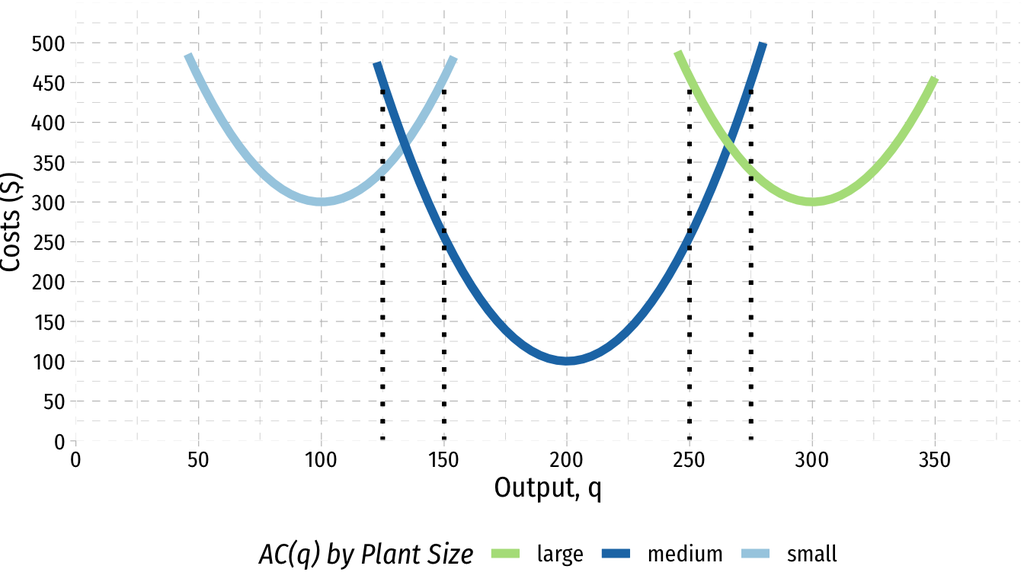

### Part A

#### If Mike wanted to produce 125 bikes, what size plant should be used, and why? What about 150 bikes?

Mike should use a small plant for 125 bikes. Even though both a small and a medium plant could produce 125, the small plant can do it cheaper (it’s AC is lower than the medium plant’s AC). Mike should use the medium plant to produce 150 bikes, because it offers a lower AC than the small plant for that range of output.

### Part B

#### If Mike wanted to produce 250 bikes, what size plant should be used, and why? What about 275 bikes?

Mike should use a medium plant for 250 bikes. Even though both a medium and a large plant could produce 250, the medium plant can do it cheaper (it’s AC is lower than the large plant’s AC). Mike should use the large plant to produce 275 bikes, because it offers a lower AC than the medium plant for that range of output.

### Part C

#### Draw the *long run average cost curve* on the graph provided (or sketch one yourself).

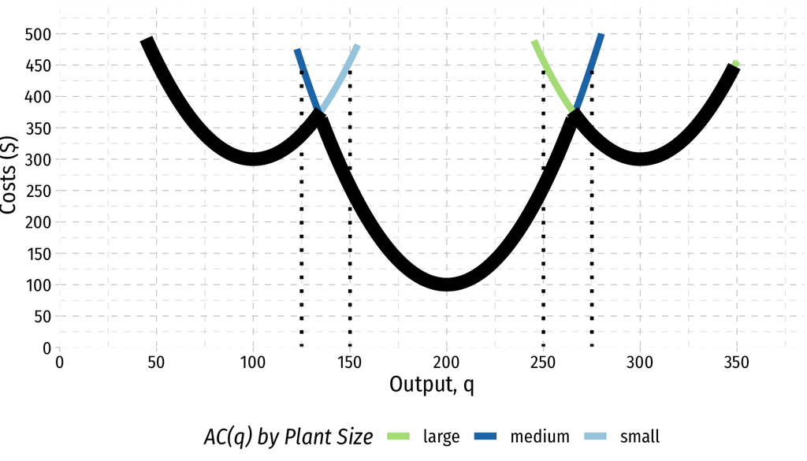

The long run average cost curve consists of the section of each short run average cost curve that is lower than that any other short run average cost curve that overlaps that range of output. It “envelopes” the lowest section of each short run average costs curve. It is shaded more heavily on the graph.

### Part D

#### Suppose Mike’s long run total cost function can be roughly expressed as:

$$LRC(q)=\frac{1}{64}q^3-6.25q^2+725q$$
with a long run marginal cost function of

$$LRMC(q)=\frac{3}{64}q^2-12.5q+725$$

#### Find the quantity of bikes where long run average cost is minimized. Plot this point on your graph. At what range of production does Mike experience economies of scale? At what range of production does Mike experience diseconomies of scale?

First, we need to find LRAC(q).

$$\begin{aligned}
LRAC(q) &= \frac{LRC(q)}{q}\\
&= \cfrac{\frac{1}{64}q^3-6.25q^2+725q}{q}\\
&= \frac{1}{64}q^2-6.25q+725\\
\end{aligned}$$

We know that LRAC(q) is minimized where it is equal to LRMC(q), so:

$$\begin{aligned}
LRAC(q)&= LRMC(q) & & \text{Minimum of }LRAC(q)\\
\frac{1}{64}q^2-6.25q+725&=\frac{3}{64}q^2-12.5q+725 & & \text{Plugging in Equations}\\
\frac{1}{64}q^2-6.25q&=\frac{3}{64}q^2-12.5q & & \text{Subtracting 725}\\
-6.25q&=\frac{2}{64}q^2-12.5q & & \text{Subtracting } \frac{1}{64}q^2\\
6.25q&=\frac{2}{64}q^2 & & \text{Adding }12.5q\\
6.25&=\frac{2}{64}q & & \text{Dividing by }q\\
200 &=q^* & & \text{Multiplying by } \frac{64}{2}\\
\end{aligned}$$

Average cost is minimized at 200 bikes. This is also the logical minimum value according to the graph. Since this is a $U$-shaped curve:

- $q < 200$: economies of scale
- $q > 200$: diseconomies of scale

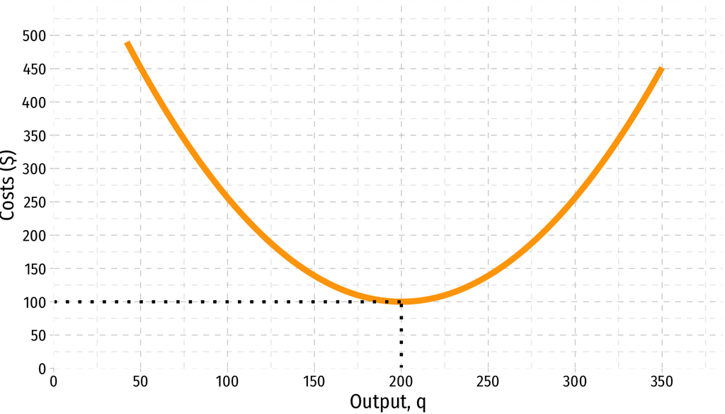

It is not asked, but if you want to calculate what is the minimum average cost, plug in 200 to the average cost function:

$$\begin{aligned}
LRAC(q) &= \frac{1}{64}1^2-6.25y+725\\
LRAC(200) &=\frac{1}{64}(200)^2-6.25(200)+725\\
LRAC(200) &=\frac{1}{64}(40,000)-1,250+725\\
LRAC(200) &=625-1,250+725\\
LRAC(200) &=\$100\\
\end{aligned}$$

## Question 6

#### Daniel’s Midland Archers has the following cost structure for producing archery bows:

$$\begin{aligned}
C(q)&=2q^2+3q+50 \\
MC(q)&=4q+3\\ \end{aligned}$$

### Part A

#### Write an equation for fixed costs, $f$.

Fixed costs are where costs don’t change with output, so any term(s) where there is no variable $q$ in them: 50. We could also see that if $q=0$:

$$\begin{aligned}
C(q)&=2q^2+3q+50\\
C(0)&=2(0)^2+3(0)+50\\
C(0)&=50\\
\end{aligned}$$

### Part B

#### Write an equation for variable costs, $VC(q)$.

Variable costs change with output, so any term(s) with a variable $q$ in them:

$$\begin{aligned}
VC(q)&=2q^2+3q\\
\end{aligned}$$

### Part C

#### Write an equation for average fixed costs, $AFC(q)$.

$$\begin{aligned}
AFC(q)&=\frac{FC}{q}\\
&=\frac{50}{q}\\
\end{aligned}$$

### Part D

#### Write an equation for average variable costs, $AVC(q)$.

$$\begin{aligned}
AVC(q)&=\frac{VC(q)}{q}\\
&=\frac{2q^2+3q}{q}\\
&=2q+3\\
\end{aligned}$$

### Part E

#### Write an equation for average (total) costs, $AC(q)$.

$$\begin{aligned}
AC(q)&=\frac{C(q)}{q}\\
&=\frac{2q^2+3q+50}{q}\\
&=2q+3+\frac{50}{q}\\
\end{aligned}$$

Alternatively, we know that:

$$\begin{aligned}
AC(q)&=AVC(q)+AFC(q)\\
&=(2q+3)+(\frac{50}{q})\\
&=2q+3+\frac{50}{q}\\
\end{aligned}$$

The graph below visualizes all costs:

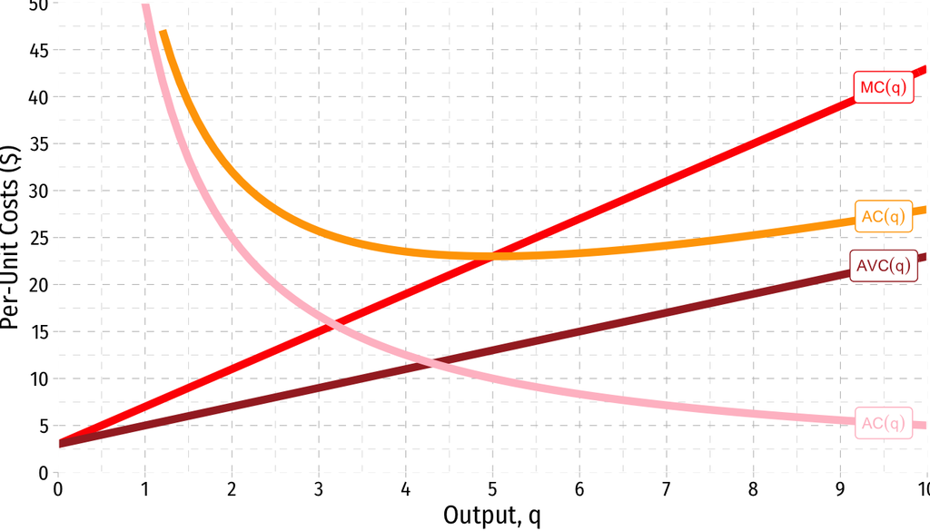

### Part F

#### At what price does Daniel’s Midland Archers break even?

We know that a competitive firm earns no profits where $p=AC(q)$. Since in competitive markets $p=MR(q)$ and firms are always setting $MR(q)=MC(q)$, we are looking for the quantity $q^*$ where:

$$\begin{aligned}
AC(q)&=MC(q) & & \text{Minimum of }AC\\
2q+3+\frac{50}{q}&=4q+3 & & \text{Filling in equations}\\
2q+\frac{50}{q}&=4q & & \text{Subtracting }3\\
2q^2+50&=4q^2 & & \text{Multiplying by }q\\
50&=2q^2 & & \text{Subtracting }2q^2\\
25&=q^2 & & \text{Dividing by }2\\
5&= q & & \text{Square rooting}\\
\end{aligned}$$

Average cost at an output of 5 is:

$$\begin{aligned}
AC(q)&=2q+3+\frac{50}{q}\\
AC(5)&=2(5)+3+\frac{50}{(5)}\\
&=10+3+10\\
&=\$23 \\
\end{aligned}$$

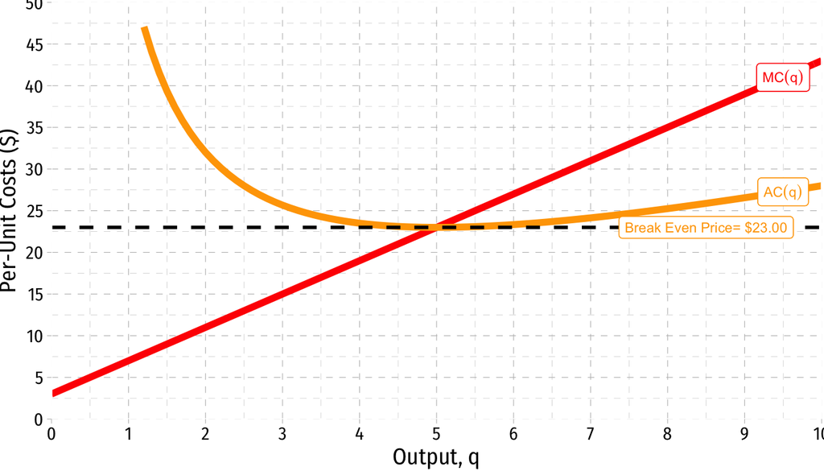

### Part G

#### Below what price would Daniel’s Midland Archers shut down in the short-run?

We know that a competitive firm shuts down where $p<AVC(q)$, so let’s find the price where $p=AVC(q)$. Since in competitive markets $p=MR(q)$ and firms are always setting $MR(q)=MC(q)$, we are looking for the quantity $q$ where:

We know this happens where:

$$\begin{aligned}
AVC(q)&=MC(q)\\
2q+3&=4q+3\\
2q&=4q\\
0&=2q\\
0&=q\\
\end{aligned}$$

This is is the quantity, now let’s plug in $q=0$ into either of these equations to find the actual price:

$$\begin{aligned}
AVC(0)&=2(0)+3\\
AVC(0)&=\$3\\
\end{aligned}$$

The shut down price is $3.

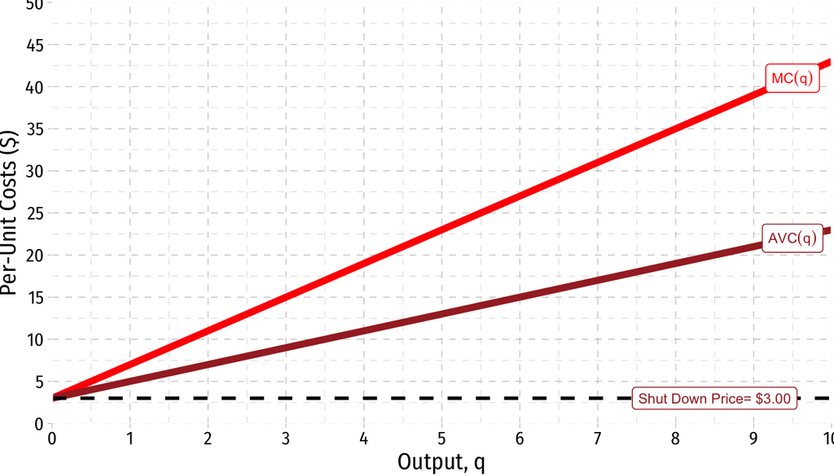

### Part H

#### Write an equation for the firm’s short-run inverse supply curve, and sketch a rough graph.

The firm chooses $q^*$ such that:

$$\begin{aligned}
MR(q) &= MC(q)\\
p&= 4q+3\\
\end{aligned}$$

The vertical intercept of $3 is the choke price, where the firm decides to not produce. This is because $3 is the minimum average variable cost, so any price lower than that would incur the firm’s shut down condition:

$$\begin{aligned}
\text{Firm's Short Run Inverse Supply}&= \left\{
\begin{array}{ll}
MC(q) & \text{if } p \geq AVC \\
q=0 & \text{if } p < AVC\\
\end{array}
\right. \\
&= \left\{
\begin{array}{ll}
p=4q+3 & \text{if } p \geq \$3 \\
q=0 & \text{if } p < \$3\\
\end{array}
\right. \\
\end{aligned}$$

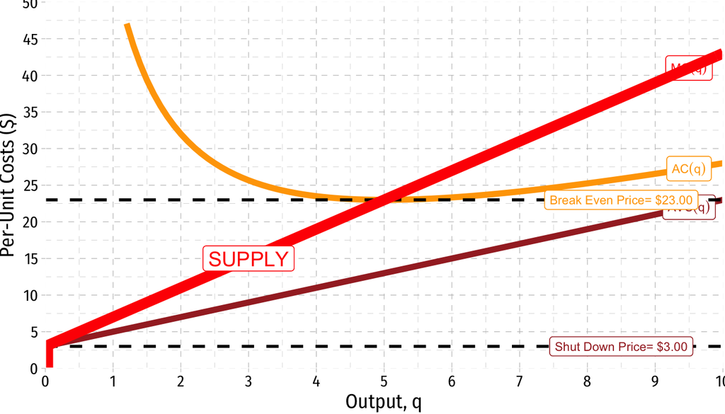

### Part I

#### What differences would there be between how Daniel’s Midland Archers decides to produce in the short run versus the long run?

The firm will only produce in the long run if it earns no losses, that is, if $p \geq AC(q)$:

$$\begin{aligned}
\text{Firm's Long Run Inverse Supply}&= \left\{
\begin{array}{ll}
MC(q) & \text{if } p \geq AC \\
q=0 & \text{if } p < AC\\
\end{array}
\right. \\
&= \left\{
\begin{array}{ll}
p=4q+3 & \text{if } p \geq \$23 \\
q=0 & \text{if } p < \$23\\
\end{array}
\right. \\
\end{aligned}$$

In the short run, even under losses, the firm will still produce so long as $p>AVC$, compare to our answer in part (h).

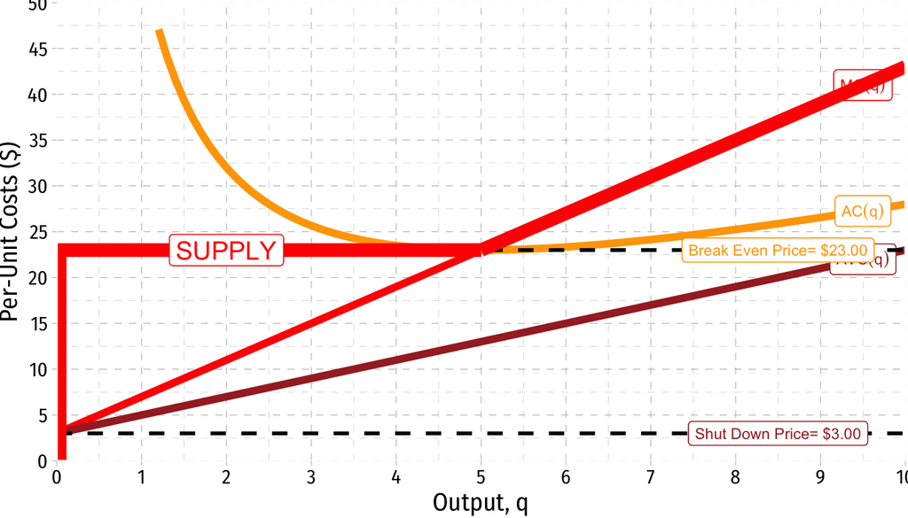

### Part J

#### In the long run, with many identical sellers of archery bows, what would be the equilibrium price?

The long run equilibrium price must yield no profits (or else there would be entry or exit). Profit is 0 where $p=AC$. Since firms always set $p=MC$, it must be the case that $AC=MC$, which happens at the minimum of the average cost curve, and we saw the break-even price was $23.

The market price must be $23: any price higher would induce entry, any price lower would induce exit.

## Question 7

#### Assume that consumers view tax preparation services as undifferentiated among producers, and that there are hundreds of companies offering tax preparation in a given market. The current market equilibrium price is $120. Joe Audit’s Tax Service has a daily short-run cost structure given by

$$\begin{aligned}
C(q)&=100+4q^2 \\
MC(q)&=8q\\ \end{aligned}$$

### Part A

#### How many tax returns should Joe prepare each day if his goal is to maximize profits?

Joe is in a perfectly competitive market, so he will prepare up to the quantity where $p=MR(q)=MC(q)$.

$$\begin{aligned}
p&=MC(q)\\
120&=8q\\
15&=q^*\\
\end{aligned}$$

He will prepare 15 tax returns per day to maximize profits.

The following graph will help visualize all the parts of this question:

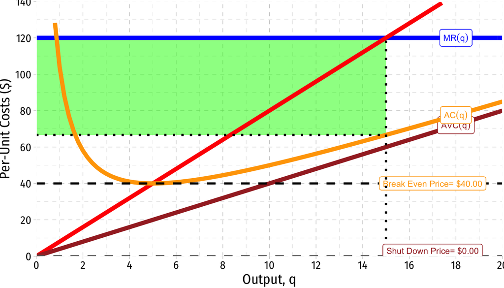

### Part B

#### How much profit will he earn each day?

Profit is total revenues minus total costs:

$$\begin{aligned}
\pi &= pq-C(q)\\
\pi &=(120)(15)-(100+4q^2)\\
\pi &= 1800-(100+4(15)^2)\\
\pi &= 1800-1000\\
\pi &= \$800\\
\end{aligned}$$

His profits are $800 (per day).

Alternatively, we could calculate profits as price minus average costs times quantity. First we would need to find average costs at $q^*=15$:

$$\begin{aligned}
AC(q)&=\frac{100}{q}+4q\\
AC(15)&=\frac{100}{15}+4(15)\\
AC(15)&\approx 6.67+60\\
AC(15)&\approx 66.67\\
\end{aligned}$$

Knowing this, we plug it into the formula for profits using price and average costs:

$$\begin{aligned}
\pi &=(p-AC(q^*))q^*\\
\pi &\approx(120-66.67)15\\
\pi &\approx(53.33)15\\
\pi &\approx \$800\\
\end{aligned}$$

### Part C

#### At what market price would Joe break even?

A firm breaks even where its Average cost equals its marginal cost. We aren’t given average cost, so we first need to find it by taking total cost and dividing by quantity:

$$\begin{aligned}
AC(q)&=\frac{C(q)}{q}\\
AC(q)&=\frac{100+4q^2}{q}\\
AC(q)&=\frac{100}{q}+4q\\
\end{aligned}$$

Now we know that average cost is minimized where:

$$\begin{aligned}
AC(q)&=MC(q)\\
\frac{100}{q}+4q&=8q \\
\frac{100}{q}&=4q\\
100&=4q^2 \\
25&=q^2 \\
5&=q^*\\
\end{aligned}$$

We know the quantity but we need to find the *price* where the firm breaks even, so plugging this back into average cost:

$$\begin{aligned}
AC(q)&=\frac{100}{q}+4q\\
AC(5)&=\frac{100}{(5)}+4(5)\\
AC(5)&=20+20\\
AC(5)&=40\\
\end{aligned}$$

Joe will break even, and earn normal profits of 0 if the market price were $40 per tax return.

### Part D

#### Below what hypothetical price would Joe shut down in the short run?

A firm shuts down in the short run when it can no longer cover its average variable costs. We know the minimum average variable cost happens when it is equal to marginal cost. Since we are not given it, we first need to find average variable costs.

$$\begin{aligned}
AVC(q)&=\frac{VC(q)}{q}\\
AVC(q)&=\frac{4q^2}{q}\\
AVC(q)&=4q\\
\end{aligned}$$

Now we know $AVC$ is minimized where:

$$\begin{aligned}
AVC(q) &= MC(q)\\
4q &= 8q \\
q&=0 \\
\end{aligned}$$

Average variable cost is minimized when Joe produces no output.

Let’s check and see what price has an output of 0, by using either the $AVC(q)$ or $MC(q)$ curves:

$$\begin{aligned}
AVC(q)&=4q\\
AVC(0)&=4(0)\\
AVC(0)&=\$0\\
\end{aligned}$$

So Joe would shut down only when the price is less than $0 (which can’t happen). This happens when the AVC function is not a curve, but a straight line starting at the origin.